# R ile Çevrimiçi Veri İndirme

Prof. Dr. Hüseyin Taştan

Yıldız Teknik Üniversitesi

08 February 2024

Bu dokümanda R programı için yazılmış veri indirme paketleri tanıtılmıştır. Bazı çevrimiçi veri tabanları kişisel API oluşturulmasını gerektirmektedir.

# 1 Finansal Veriler

```r
library(tidyverse)
```

## 1.1 `{quantmod}` Paketi

(Quantitative Financial Modelling & Trading Framework for R)

Websitesi: https://www.quantmod.com/

```r
# install.packages("quantmod")
library(quantmod)
```

**ÖRNEK**: Apple hisse senedinin günlük verilerini 01-01-2018-24-03-2023 arasını kapsayacak şekilde indirelim:

```r
# yil-ay-gün
getSymbols("AAPL", from='2018-01-01',to='2023-03-24')
```

```
## [1] "AAPL"
```

`AAPL` bir `xts` nesnesi olarak tanımlıdır.

```r
class(AAPL)
```

```
## [1] "xts" "zoo"
```

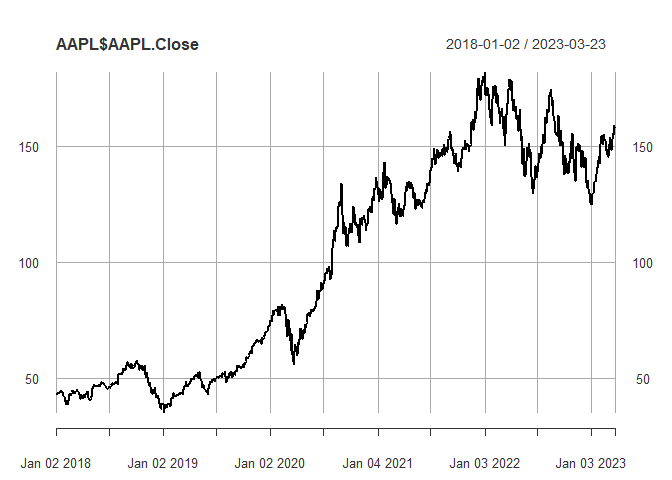

```r
# APPLE hisselerinin günlük kapanış fiyatları
plot(AAPL$AAPL.Close)
```

`quantmod:ChartSeries()` fonksiyonu ile görselleştirme:

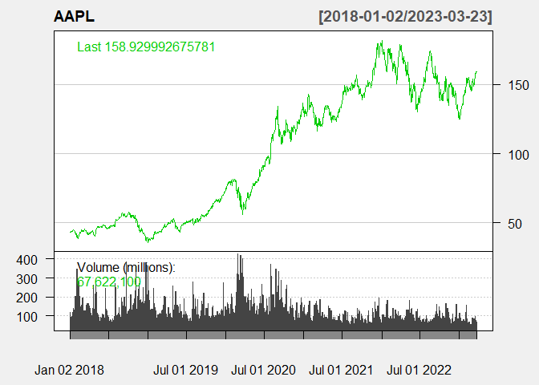

```r
chartSeries(AAPL,
            type="line",
            theme=chartTheme('white'))
```

Sadece 2020 yılı:

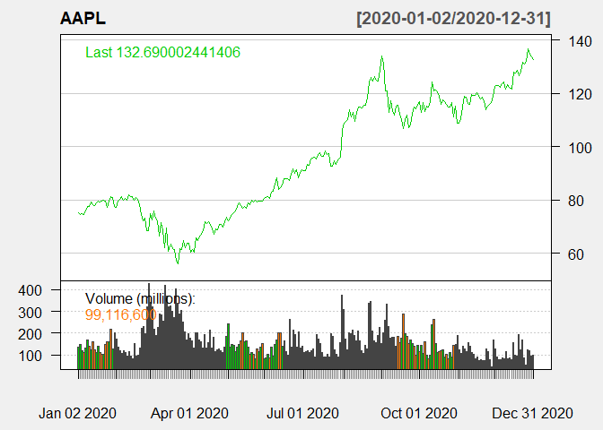

```r
chartSeries(AAPL,
            type="line",
            subset='2020',
            theme=chartTheme('white'))
```

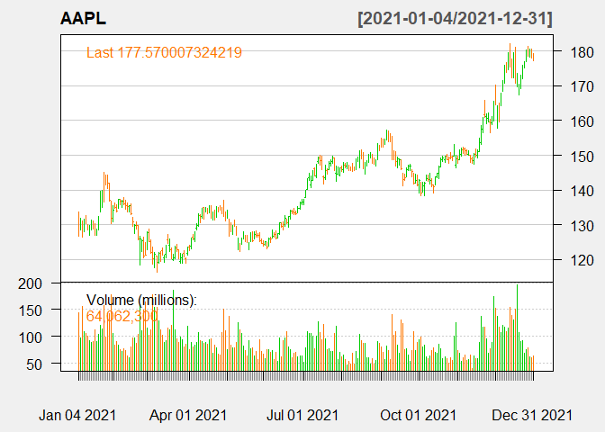

```r
chartSeries(AAPL,
            type="bar",
            subset="2021",
            theme=chartTheme('white'))
```

Candle stick plot:

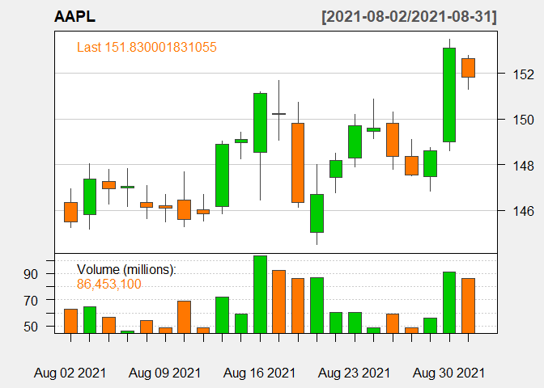

```r
chartSeries(AAPL,
            type="candlesticks",
            subset="2021-08",
            theme=chartTheme('white'))
```

**Örnek**: Google hisselerinin günlük getiri oranları hesaplayarak grafiğini çizelim:

```r
# GOOGLE hissesinin getiri oranı
library(quantmod)
getSymbols("GOOG")
```

```
## [1] "GOOG"
```

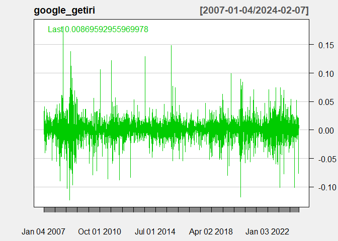

```r
google_getiri <- diff(log(GOOG$GOOG.Adjusted)) # log getiri  oranı
chartSeries(google_getiri, theme="white")
```

**Örnek**: Bitcoin günlük fiyatlar:

```r
getSymbols("BTC-USD")
```

```
## [1] "BTC-USD"
```

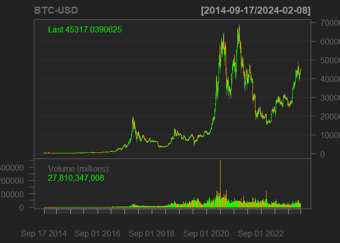

```r
chartSeries(`BTC-USD`)
```

**Örnek**: BIST100 Endeksi (Son dönem verileri güncellenmiyor)

```r
# BIST100 endeksinin verileri Yahoo Finansta eksik:
quantmod::getSymbols("^XU100", from='2018-01-01',to='2023-03-24')
```

```
## [1] "XU100"
```

## 1.2 `{tidyquant}` Paketi

Finansal verilerin indirilmesi ve analizi için kullanabileceğimiz başka bir paket `{tidyquant}` paketidir. Bu paket `{tidyverse}` paketleri ile uyumlu çalışacak şekilde geliştirilmiştir.

Daha fazla detay için bkz. https://business-science.github.io/tidyquant/

```r
# install.packages("tidyquant")
library(tidyquant)
```

```r
# Microsoft hisse fiyatları
# similar to quantmod::getSymbols()
microsoft <- tq_get(x = "MSFT")
head(microsoft)
```

```
## # A tibble: 6 × 8
##   symbol date        open  high   low close   volume adjusted
##   <chr>  <date>     <dbl> <dbl> <dbl> <dbl>    <dbl>    <dbl>
## 1 MSFT   2014-01-02  37.3  37.4  37.1  37.2 30632200     31.3
## 2 MSFT   2014-01-03  37.2  37.2  36.6  36.9 31134800     31.1
## 3 MSFT   2014-01-06  36.8  36.9  36.1  36.1 43603700     30.4
## 4 MSFT   2014-01-07  36.3  36.5  36.2  36.4 35802800     30.7
## 5 MSFT   2014-01-08  36    36.1  35.6  35.8 59971700     30.1
## 6 MSFT   2014-01-09  35.9  35.9  35.4  35.5 36516300     29.9
```

```r
# data is in tibble format
```

```r
# tidyquant::tq_get() is a wrapper for quantmod::getSymbols() but provides
# additional data resources such as crypto assets
tq_get_options()
```

```
##  [1] "stock.prices"       "stock.prices.japan" "dividends"
##  [4] "splits"             "economic.data"      "quandl"
##  [7] "quandl.datatable"   "tiingo"             "tiingo.iex"
## [10] "tiingo.crypto"      "alphavantager"      "alphavantage"
## [13] "rblpapi"
```

Piyasa bilgilerini indirmek için:

```r
tq_exchange_options()
```

```
## [1] "AMEX"   "NASDAQ" "NYSE"
```

Örneğin

```r
# nyse <- tq_exchange("NYSE")
# head(nyse)
```

```r
# endeks verileri için,
tq_index_options()
```

```
## [1] "DOW"       "DOWGLOBAL" "SP400"     "SP500"     "SP600"
```

```r
# örneğin
sp500 <- tq_index("SP500")
```

```
## Getting holdings for SP500
```

```r
# SP500 içindeki hisse fiyatları
tq_index("SP500") %>%
    slice(1:3) %>% # sadece ilk 3 hisse
    tq_get(get = "stock.prices")
```

```
## Getting holdings for SP500
```

```
## # A tibble: 7,626 × 15
##    symbol company      identifier sedol weight sector shares_held local_currency
##    <chr>  <chr>        <chr>      <chr>  <dbl> <chr>        <dbl> <chr>
##  1 MSFT   MICROSOFT C… 594918104  2588… 0.0734 -         85568020 USD
##  2 MSFT   MICROSOFT C… 594918104  2588… 0.0734 -         85568020 USD
##  3 MSFT   MICROSOFT C… 594918104  2588… 0.0734 -         85568020 USD
##  4 MSFT   MICROSOFT C… 594918104  2588… 0.0734 -         85568020 USD
##  5 MSFT   MICROSOFT C… 594918104  2588… 0.0734 -         85568020 USD
##  6 MSFT   MICROSOFT C… 594918104  2588… 0.0734 -         85568020 USD
##  7 MSFT   MICROSOFT C… 594918104  2588… 0.0734 -         85568020 USD
##  8 MSFT   MICROSOFT C… 594918104  2588… 0.0734 -         85568020 USD
##  9 MSFT   MICROSOFT C… 594918104  2588… 0.0734 -         85568020 USD
## 10 MSFT   MICROSOFT C… 594918104  2588… 0.0734 -         85568020 USD
## # ℹ 7,616 more rows
## # ℹ 7 more variables: date <date>, open <dbl>, high <dbl>, low <dbl>,
## #   close <dbl>, volume <dbl>, adjusted <dbl>
```

## 1.3 `{Quandl}` Paketi

Visit https://data.nasdaq.com/.

```r
# install.packages("Quandl")
library(Quandl)
```

Örnekler için bkz.

https://github.com/quandl/quandl-r.

ve

https://data.nasdaq.com/tools/r

API anahtarı olmadan veri indirmenin günlük sınırı vardır. Bu nedenle API anahtarı girilmesi tavsiye edilir.

# 2 Dünya Bankası Verileri

## 2.1 `{WDI}` Paketi

Kullanım klavuzu ve örnekler için bkz. https://github.com/vincentarelbundock/WDI

```r
# install.packages("WDI")
library(WDI)
```

**Örnek** Meksika, Türkiye, G. Kore, Malezya, ve ABD için kişi başına gayrisafi yurt içi hasıla (2015 sabit USD fiyatları ile):

```r
gdppc = WDI(indicator = 'NY.GDP.PCAP.KD',
            country = c('MEX','TUR', 'KOR', 'MYS', 'USA'),
            start = 1960,
            end = 2021)
head(gdppc)
```

```
##       country iso2c iso3c year NY.GDP.PCAP.KD
## 1 Korea, Rep.    KR   KOR 2021       32786.69
## 2 Korea, Rep.    KR   KOR 2020       31378.16
## 3 Korea, Rep.    KR   KOR 2019       31645.95
## 4 Korea, Rep.    KR   KOR 2018       31059.27
## 5 Korea, Rep.    KR   KOR 2017       30312.89
## 6 Korea, Rep.    KR   KOR 2016       29467.12
```

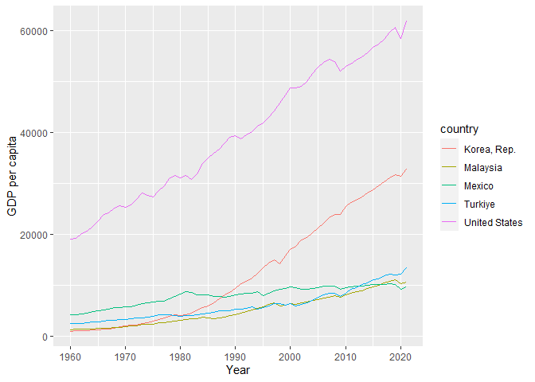

```r
gdppc |> ggplot(aes(year, NY.GDP.PCAP.KD, color = country)) +
  geom_line() +
  scale_x_continuous(breaks = seq(1960,2020,10)) +
  labs(x = "Year",
       y = "GDP per capita")
```

## 2.2 `{wbstats}` Paketi

Kullanım klavuzu ve örnekler için bkz. https://cran.r-project.org/web/packages/wbstats/vignettes/wbstats.html

```r
# install.packages("wbstats")
library(wbstats)
```

```r
pop_data <- wb_data("SP.POP.TOTL", start_date = 2000, end_date = 2002)
head(pop_data)
```

```
## # A tibble: 6 × 9
##   iso2c iso3c country    date SP.POP.TOTL unit  obs_status footnote last_updated
##   <chr> <chr> <chr>     <dbl>       <dbl> <chr> <chr>      <chr>    <date>
## 1 AW    ABW   Aruba      2000       89101 <NA>  <NA>       <NA>     2023-12-18
## 2 AW    ABW   Aruba      2001       90691 <NA>  <NA>       <NA>     2023-12-18
## 3 AW    ABW   Aruba      2002       91781 <NA>  <NA>       <NA>     2023-12-18
## 4 AF    AFG   Afghanis…  2000    19542982 <NA>  <NA>       <NA>     2023-12-18
## 5 AF    AFG   Afghanis…  2001    19688632 <NA>  <NA>       <NA>     2023-12-18
## 6 AF    AFG   Afghanis…  2002    21000256 <NA>  <NA>       <NA>     2023-12-18
```

```r
# Örnek: NÜfus ve GDP verileri, tüm ülkeler, 1980-2021
my_indicators = c("pop" = "SP.POP.TOTL",
                  "gdp" = "NY.GDP.MKTP.CD")

pop_gdp <- wb_data(my_indicators, start_date = 1980, end_date = 2021)
head(pop_gdp)
```

```
## # A tibble: 6 × 6
##   iso2c iso3c country  date   gdp   pop
##   <chr> <chr> <chr>   <dbl> <dbl> <dbl>
## 1 AW    ABW   Aruba    1980    NA 62267
## 2 AW    ABW   Aruba    1981    NA 62614
## 3 AW    ABW   Aruba    1982    NA 63116
## 4 AW    ABW   Aruba    1983    NA 63683
## 5 AW    ABW   Aruba    1984    NA 64174
## 6 AW    ABW   Aruba    1985    NA 64478
```

# 3 Penn World Tables

Yaygın olarak kullanılan ülkeler arası başka bir veri tabanı Penn World Tables’dır. Son sürümü için bkz. https://www.rug.nl/ggdc/productivity/pwt/?lang=en

## 3.1 `{pwt}` Paketi

CRAN websitesi için bkz. https://cran.r-project.org/web/packages/pwt10/index.html

En son versiyon: pwt10.0,

```r
# install.packages("pwt10")
library(pwt10)
data(pwt10.0)
# değişkenlerin tanımları için bkz.
# ?pwt10.0
```

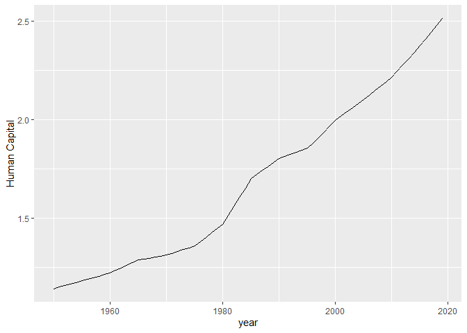

```r
pwt10.0 |> filter(country=="Turkey") |>
  ggplot(aes(year, hc)) +
  geom_line() +
  labs(y = "Human Capital")
```

# 4 Federal Reserve Bank of St. Louis Veri Tabanı: FRED

Özellikle ABD verileri için zengin bir veri kaynağı sunmaktadır. Ayrıca çok sayıda ülke verisi de bulunmaktadır. FRED websitesi için bkz. https://fred.stlouisfed.org/

FRED’den veri indirmek için `quantmod` paketi kullanılabilir. Ayrıca geliştirilmiş paketler de bulunmaktadır.

## 4.1 `{fredr}` Paketi

Kullanıma klavuzu için bkz.http://sboysel.github.io/fredr/articles/fredr.html ve https://sboysel.github.io/fredr/

```r
# install.packages("fredr")
library(fredr)
```

Paketi kullanabilmek için FRED’den API KEY alınması gerekmektedir. Detaylar için bkz. https://fred.stlouisfed.org/docs/api/api_key.html

# 5 Food and Agricultural Organization (FAO) Statistics

## 5.1 `{FAOSTAT}` Paketi

For more information visit

https://gitlab.com/paulrougieux/faostatpackage

and

https://cran.r-project.org/web/packages/FAOSTAT/index.html

For bulk download: https://github.com/muuankarski/faobulk

For vignettes:

```r
vignette(topic = "FAOSTAT")
```

```r
library(FAOSTAT)
```

# 6 Eurostat Open Data

## 6.1 `{eurostat}` Paketi

https://cran.r-project.org/web/packages/eurostat/index.html

https://ropengov.github.io/eurostat/articles/eurostat_tutorial.html

```r
library(eurostat)
```

```r
# Table of contents
toc <- get_eurostat_toc()
```

```r
# Örnek
# Konut fiyat endeksi, çeyreklik
HPI <- get_eurostat("ei_hppi_q", time_format = "date")
```

```
## Dataset query already saved in cache_list.json...
```

```
## Reading cache file C:\Users\hntas\AppData\Local\Temp\Rtmpiw8JZg/eurostat/efa8ca5cb67bea1b67a5d1922942953d.rds
```

```
## Table  ei_hppi_q  read from cache file:  C:\Users\hntas\AppData\Local\Temp\Rtmpiw8JZg/eurostat/efa8ca5cb67bea1b67a5d1922942953d.rds
```

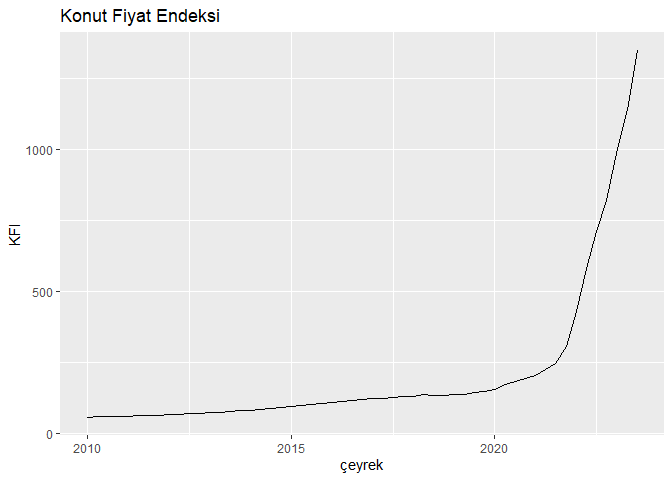

```r
# TR verileri
tr_hpi <- HPI |> filter(unit=="I15_NSA", geo=="TR") |>
  select(TIME_PERIOD, values) |>
  rename(çeyrek = TIME_PERIOD,
         KFI = values)
# plot
tr_hpi |> ggplot(aes(çeyrek, KFI)) +
  geom_line() +
  labs(title = "Konut Fiyat Endeksi")
```

# 7 OECD Data

## 7.1 `{OECD}` Paketi

https://cran.r-project.org/web/packages/OECD/index.html

https://github.com/expersso/OECD

```r
library(OECD)
```

# 8 IMF Data

## 8.1 `{IMFData}` Paketi

https://github.com/mingjerli/IMFData

```r
devtools::install_github('mingjerli/IMFData')
```

# 9 Kripto varlık fiyatları

## 9.1 `{crypto2}` Paketi

Bu paket https://coinmarketcap.com sitesinden kripto varlık fiyatlarını indirmek için tasarlanmıştır. Daha fazla bilgi ve örnekler için bkz.

https://github.com/sstoeckl/crypto2

```r
library(tidyverse)
library(crypto2)
coins <- crypto_list(only_active=TRUE)
head(coins)
```

```
## # A tibble: 6 × 8
##      id  rank name      symbol slug      is_active first_historical_data
##   <int> <int> <chr>     <chr>  <chr>         <int> <date>
## 1     1     1 Bitcoin   BTC    bitcoin           1 2010-07-13
## 2     2    19 Litecoin  LTC    litecoin          1 2013-04-28
## 3     3  1092 Namecoin  NMC    namecoin          1 2013-04-28
## 4     4  7501 Terracoin TRC    terracoin         1 2013-04-28
## 5     5   960 Peercoin  PPC    peercoin          1 2013-04-28
## 6     6  6204 Novacoin  NVC    novacoin          1 2013-04-28
## # ℹ 1 more variable: last_historical_data <date>
```

```r
coin_data <- crypto_history(coins, limit=3, start_date="20220101", end_date="20240207", finalWait=FALSE)
```

```
## ❯ Scraping historical crypto data
```

```
## ❯ Processing historical crypto data
```

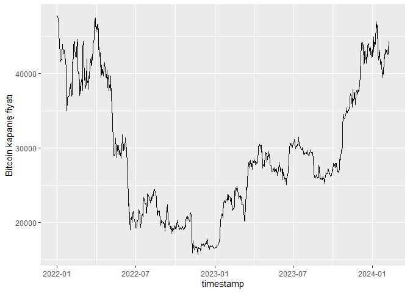

```r
coin_data |> filter(symbol == "BTC") |>
  ggplot(aes(timestamp, close)) +
  geom_line() +
  labs(y="Bitcoin kapanış fiyatı")
```